# LandR *Biomass_speciesData* Manual

Last updated: 2026-10-22

#### Authors:

Ceres Barros ceres.barros@ubc.ca [aut, cre], Eliot J B McIntire eliot.mcintire@nrcan-rncan.gc.ca [aut], Alex M. Chubaty achubaty@for-cast.ca [aut]

**This documentation is work in progress. Potential discrepancies and omissions may exist for the time being. If you find any, contact us using the “Get help” link above.**

## Module Overview

### Quick links

- General functioning
- List of input objects
- List of parameters
- List of outputs
- Simulation flow and module events

### Module summary

LandR *Biomass_speciesData* (hereafter *Biomass_speciesData*) downloads and pre-processes species percent (% cover) data layers used by other LandR data modules (e.g., *Biomass_borealDataPrep*) and by the LandR forest simulation module *Biomass_core*.

### Links to other modules

*Biomass_speciesData* is intended to be used with any LandR modules that require species % cover raster layers (see examples below). See [here](https://rpubs.com/PredictiveEcology/LandR_Module_Ecosystem) for all available modules in the LandR ecosystem and select *Biomass_speciesData* from the drop-down menu to see potential linkages.

- [*Biomass_borealDataPrep*](https://github.com/PredictiveEcology/Biomass_borealDataPrep): prepares all parameters and inputs (including initial landscape conditions) that *Biomass_core* needs to run a realistic simulation. Default values/inputs produced are relevant for boreal forests of Western Canada. Used downstream from *Biomass_speciesData*;
- [*Biomass_core*](https://github.com/PredictiveEcology/Biomass_core): core forest dynamics simulation module. Used downstream from *Biomass_speciesData*.

## Module manual

### General functioning

Currently, the module can access the following datasets: - Canadian National Forest Inventory (NFI) forest attributes kNN dataset [`KNN`; Beaudoin *et al.* (2014), Beaudoin *et al.* (2017)]; - Common Attribute Schema for Forest Resource Inventories [`CASFRI` (v4); Cosco (2011)], - Spatialized Canadian National Forest Inventory [`SCANFI`; Guindon *et al.* (2023), Guindon *et al.* (2024)]; - National Terrestrial Ecosystem Monitoring System for Canada Annual Tree Species [`NTEMS`; Hermosilla *et al.* (2024)]; - Manitoba Forest Resource Inventory (`MBFRI`); - Ontario Forest Resource Inventory (`ONFRI`); - historical dataset specific to Western Canada compiled by Paul Pickell and Nicholas Coops (Pickell & Coops 2016) as part of the LandWeb project; - “current conditions” dataset specific to Western Canada compiled from forest resource inventories as part of the LandWeb project (`ForestInventory`);

However, **only the NFI kNN data are freely available** and access to the other datasets must be granted by module developers and data owners, and requires a Google account. Nevertheless, the module is flexible enough that any user can use it to process additional datasets, provided that an adequate R function is passed to the module (see `types` parameter details in the list of parameters).

When multiple data sources are used, the module will replace lower quality data with higher quality data following the order specified in the `types` parameter.

When multiple species of a given data source are to be grouped, % cover is summed across species of the same group within each pixel. Please see the `sppEquiv` in the list of input objects for information on how to define species groups.

The module can also exclude species % cover layers if they don’t have a minimum % cover value in at least one pixel. The user should still inspect where species is deemed present (e.g., in how many pixels in total), as it is possible that some datasets only have a few pixels where the species is present, but with reported high % cover. In this case, the user may choose to exclude these species *a posteriori*. The summary plot automatically shown by *Biomass_speciesData* can help diagnose whether certain species are present in very few pixels (see Fig. 1).

### List of input objects

Of the inputs in Table 2, the following are particularly important and deserve special attention:

- `studyAreaLarge` – the polygon defining the area for which species cover data are desired. It can be larger (but never smaller) that the study area used in the simulation of forest dynamics (i.e., `studyArea` object in *Biomass_core*), in which case it should fully cover it.
- `sppEquiv` – a table of correspondences between different species naming conventions. This table is used across several LandR modules, including *Biomass_core*. It is particularly important here because it will determine whether and which species (and their cover layers) are merged. For instance, if the user wishes to simulate a generic *Picea spp.* that includes, *Picea glauca*, *Picea mariana* and *Picea engelmannii*, they will need to provide these three species names in the data column (e.g., `KNN` if obtaining forest attribute kNN data layers from the National Forest Inventory), but the same name (e.g., “Pice_Spp”) in the column chosen for the naming convention used throughout the simulation (defined by the `sppEquivCol` parameter). See Table 1 for an example.

| Species | KNN | Boreal | Modelled as |
| --- | --- | --- | --- |
| Abies balsamea | Abie_Bal | Abie_Bal | Abies balsamea |
| Abies lasiocarpa | Abie_Las | Abie_Las | Abies lasiocarpa |
| Picea engelmannii | Pice_Eng | Pice_Spp | Picea spp. |
| Picea engelmannii x glauca | Pice_Eng_Gla | Pice_Spp | Picea spp. |
| Picea glauca | Pice_Gla | Pice_Spp | Picea spp. |
| Picea mariana | Pice_Mar | Pice_Spp | Picea spp. |
| Pinus contorta var. latifolia | Pinu_Con | Pinu_Con | Pinus contorta var. latifolia |

Table 2: List of *Biomass_speciesData* input objects and their description.

| objectName | objectClass | desc | sourceURL |
| --- | --- | --- | --- |
| rasterToMatch | SpatRaster | conditionally used as template raster if studyArea_rasterToMatch_biomassParam and rasterTomatch_biomassParam are not supplied | NA |
| rasterToMatch_biomassParam | SpatRaster | a raster of `studyArea_biomassParam` in the same resolution and projection as the simulation’s. | NA |
| sppColorVect | character | A named vector of colors to use for plotting. The names must be in `sim$sppEquiv[[sim$sppEquivCol]]`, and should also contain a color for ‘Mixed’ | NA |
| sppEquiv | data.table | table of species equivalencies. See `LandR::sppEquivalencies_CA`. |  |
| sppNameVector | character | an optional vector of species names to be pulled from `sppEquiv`. Species names must match `P(sim)$sppEquivCol` column in `sppEquiv`. If not provided, then species will be taken from the entire `P(sim… | NA |
| studyArea | sf | `sf` polygon or terra `SpatVector` to use as the study area - `nrow` must be one | NA |
| studyArea_biomassParam | sf | Polygon to use as the parametrisation study area. Must be provided by the user. Note that `studyArea_biomassParam` is only used for parameter estimation, and can be larger than the actual study area u… | NA |
| studyAreaReporting | sf | multipolygon (typically smaller/unbuffered than `studyArea_biomassParam` and `studyArea` in LandR `Biomass_core`) to use for plotting/reporting. If not provided, will default to `studyArea_biomassPara… | NA |

### List of parameters

Table 3 lists all parameters used in *Biomass_speciesData* and their detailed information. All these parameters have default values specified in the module’s metadata.

Of these parameters, the following are particularly important:

- `coverThresh` – integer. Defines a minimum % cover value (from 0-100) that the species must have in at least one pixel to be considered present in the study area, otherwise it is excluded from the final stack of species layers (`speciesLayers`). Note that this will affect what species have data for an eventual simulation and the user will need to adjust simulation parameters accordingly (e.g., species in trait tables will need to match the species in `speciesLayers`).
- `types` – character. Which % cover data sources are to be used (see General functioning). Several data sources can be passed, in which case the module will overlay the lower quality layers with higher quality ones following the order of data sources in `types`. For instance, if `types == c("KNN", "CASFRI", "ForestInventory")`, KNN is assumed to be the lowest quality data set and ForestInventory the highest, hence values in KNN layers are replaced with overlapping values from CASFRI layers and values from KNN and CASFRI layers are replaced with overlapping values of ForestInventory layers.

Table 3: List of *Biomass_speciesData* parameters and their description.

| paramName | paramClass | default | min | max | paramDesc | cacheKey |
| --- | --- | --- | --- | --- | --- | --- |
| coverThresh | integer | 10 | NA | NA | The minimum % cover a species needs to have (per pixel) in the study area to be considered present | TRUE |
| dataYear | numeric | 2020 | NA | NA | Passed to `paste0('prepSpeciesLayers_', types)` function to fetch data from that year (if applicable). Defaults to 2020 as the default SCANFI year. | TRUE |
| sppEquivCol | character | LandR | NA | NA | The column in `sim$sppEquiv` data.table to group species by and use as a naming convention. If different species in, e.g., the SCANFI data have the same name in the chosen column, their data are merge… | TRUE |
| types | character | SCANFI | NA | NA | The possible data sources. These must correspond to a function named `paste0('prepSpeciesLayers_', types)`. Defaults to ‘SCANFI’. Other currently available options are: ‘CASFRI’, ‘ForestInventory’, ‘K… | TRUE |
| vegLeadingProportion | numeric | 0.75 | 0 | 1 | a number that defines whether a species is leading for a given pixel. Only used for plotting. Default: `LandR::leadingSpeciesProp()`, i.e. option `LandR.leadingSpeciesProp`, which takes `LandR.mixedwo… | TRUE |
| .plotInitialTime | numeric | 0 | NA | NA | This describes the simulation time at which the first plot event should occur | TRUE |
| .plotInterval | numeric | NA | NA | NA | This describes the simulation time interval between plot events | TRUE |
| .plots | character | screen | NA | NA | Passed to `types` in `Plots` (see `?Plots`). There are a few plots that are made within this module, if set. Note that plots (or their data) saving will ONLY occur at `end(sim)`. If `NA`, plotting is … | TRUE |
| .saveInitialTime | numeric | NA | NA | NA | This describes the simulation time at which the first save event should occur | TRUE |
| .saveInterval | numeric | NA | NA | NA | This describes the simulation time interval between save events | TRUE |
| .sslVerify | integer | 64 | NA | NA | Passed to `httr::config(ssl_verifypeer = P(sim)$.sslVerify)` when downloading NFI datasets. Set to 0L if necessary to bypass checking the SSL certificate (this may be necessary when NFI’s website SSL … | TRUE |
| .studyAreaName | character | NA | NA | NA | Human-readable name for the study area used. If `NA`, a hash of `studyArea_biomassParam` will be used. | TRUE |
| .useCache | character | init | NA | NA | Controls cache; caches the init event by default | TRUE |
| .useParallel | numeric | 2 | NA | NA | Used in reading csv file with fread. Will be passed to `data.table::setDTthreads`. | TRUE |

### List of outputs

The module produces the outputs in Table 4, and automatically saves the processed species cover layers in the output path defined in `getPaths(sim)$outputPath`.

Table 4: List of *Biomass_speciesData* output objects and their description.

| objectName | objectClass | desc |
| --- | --- | --- |
| speciesLayers | SpatRaster | biomass percentage raster layers by species in Canada species map |

### Simulation flow and module events

*Biomass_speciesData* initialises itself and prepares all inputs provided that it has internet access to download the raw data layers, or that these layers have been previously downloaded and stored in the folder specified by `options("reproducible.destinationPath")`[^1].

The module defaults to processing cover data fo all species listed in the `Boreal` column of the default `sppEquiv` input `data.table` object, for which there are available % cover layers in the kNN dataset (Table 5; see `?LandR::sppEquivalencies_CA` for more information):

Table 5: List of species cover data downloaded by default by *Biomass_speciesData*.

| Species | Generic name |
| --- | --- |
| Abies balsamea | Balsam fir |
| Abies lasiocarpa | Subalpine fir |
| Acer negundo | Boxelder maple |
| Acer pensylvanicum | Striped maple |
| Acer saccharinum | Silver maple |
| Acer saccharum | Sugar maple |
| Acer spp. | Maple |
| Acer spicatum | Mountain maple |
| Alnus spp. | Alder |
| Betula alleghaniensis | Yellow birch |
| Betula papyrifera | Paper birch |
| Betula populifolia | Gray birch |
| Betula spp. | Birch |
| Fagus grandifolia | American beech |
| Fraxinus americana | American ash |
| Fraxinus nigra | Black ash |
| Fraxinus spp. | Ash |
| Larix laricina | Tamarack |
| Larix lyallii | Alpine larch |
| Larix occidentalis | Western larch |
| Larix spp. | Larch |
| Picea engelmannii | Engelmann’s spruce |
| Picea engelmannii x glauca | Hybrid white x Englemann Spruce |
| Picea glauca | White spruce |
| Picea mariana | Black spruce |
| Picea spp. | Spruce |
| Pinus albicaulis | Whitebark pine |
| Pinus banksiana | Jack pine |
| Pinus contorta var. latifolia | Lodgepole pine |
| Pinus monticola | Western white pine |
| Pinus resinosa | Red pine |
| Pinus spp. | Pine |
| Populus balsamifera | Balsam poplar |
| Populus balsamifera v. balsamifera | Balsam poplar |
| Populus grandidentata | Bigtooth aspen |
| Populus spp. | Poplar |
| Populus tremuloides | Trembling aspen |
| Populus trichocarpa | Black cottonwood |
| Tsuga canadensis | Eastern hemlock |
| Tsuga spp. | Hemlock |

*Biomass_speciesData* only runs two events, the `init` event where all species cover layers are processed and a plotting event (`initPlot`) that plots the final layers.

## Usage example

This module can be run stand-alone, but it only compiles species % cover data into layers used by other modules.

### Load `SpaDES` and other packages.

### Set up R libraries

```r
options(repos = c(CRAN = "https://cloud.r-project.org"))
tempDir <- tempdir()

pkgPath <- file.path(tempDir, "packages", version$platform,
                     paste0(version$major, ".", strsplit(version$minor, "[.]")[[1]][1]))
dir.create(pkgPath, recursive = TRUE)
.libPaths(pkgPath, include.site = FALSE)

if (!require(Require, lib.loc = pkgPath)) {
  remotes::install_github(
    paste0("PredictiveEcology/",
           "Require@5c44205bf407f613f53546be652a438ef1248147"),
    upgrade = FALSE, force = TRUE)
  library(Require, lib.loc = pkgPath)
}

setLinuxBinaryRepo()
```

### Get the module and module dependencies

```r
Require(paste0("PredictiveEcology/",
               "SpaDES.project@6d7de6ee12fc967c7c60de44f1aa3b04e6eeb5db"),
        require = FALSE, upgrade = FALSE, standAlone = TRUE)

paths <- list(inputPath = normPath(file.path(tempDir, "inputs")),
              cachePath = normPath(file.path(tempDir, "cache")),
              modulePath = normPath(file.path(tempDir, "modules")),
              outputPath = normPath(file.path(tempDir, "outputs")))

SpaDES.project::getModule(modulePath = paths$modulePath,
                          c("PredictiveEcology/Biomass_speciesData@master"),
                          overwrite = TRUE)

## make sure all necessary packages are installed:
outs <- SpaDES.project::packagesInModules(modulePath = paths$modulePath)
Require(c(unname(unlist(outs)), "SpaDES"),
        require = FALSE, standAlone = TRUE)

## load necessary packages
Require(c("SpaDES", "LandR", "reproducible"), upgrade = FALSE, install = FALSE)
```

### Setup simulation

For this demonstration we are using all default parameter values, except `coverThresh` , which is lowered to 5%. The species layers (the major output of interest) are saved automatically, so there is no need to tell `spades` what to save using the `outputs` argument (see `?SpaDES.core::outputs`).

We pass the global parameter `.plotInitialTime = 1` in the `simInitAndSpades` function to activate plotting.

```r
# User may want to set some options -- see ?reproducibleOptions
#    -- e.g., often the path to the 'inputs' folder will be set outside of project by user:
# options(reproducible.inputPaths = "E:/Data/LandR_related/") # to re-use datasets across projects
studyAreaLarge <- Cache(randomStudyArea, size = 1e7,
                        cacheRepo = paths$cachePath) # cache this so it creates a random one only once on a machine

# Pick the species you want to work with -- here we use the naming convention in "Boreal" column of LandR::sppEquivalencies_CA (default)
speciesNameConvention <- "Boreal"
speciesToUse <- c("Pice_Gla", "Popu_Tre", "Pinu_Con")

sppEquiv <- LandR::sppEquivalencies_CA[get(speciesNameConvention) %in% speciesToUse]
# Assign a colour convention for graphics for each species
sppColorVect <- LandR::sppColors(sppEquiv, speciesNameConvention,
                                 newVals = "Mixed", palette = "Set1")

## Usage example
modules <- list("Biomass_speciesData")
objects <- list("studyAreaLarge" = studyAreaLarge,
                "sppEquiv" = sppEquiv,
                "sppColorVect" = sppColorVect)
params <- list("Biomass_speciesData" = list("coverThresh" = 5L))
```

### Run module

Note that because this is a data module (i.e., only attempts to prepare data for the simulation) we are not iterating it and so both the start and end times are set to `1` here.

```r
opts <- options(
  reproducible.destinationPath = paths$inputPath,
  reproducible.useCache = TRUE
)

mySimOut <- simInitAndSpades(times = list(start = 1, end = 1),
                             modules = modules,
                             parameters = params,
                             objects = objects,
                             paths = paths,
                             .plotInitialTime = 1)
options(opts)
```

Here are some of outputs of *Biomass_speciesData* (dominant species) in a randomly generated study area within Canada.

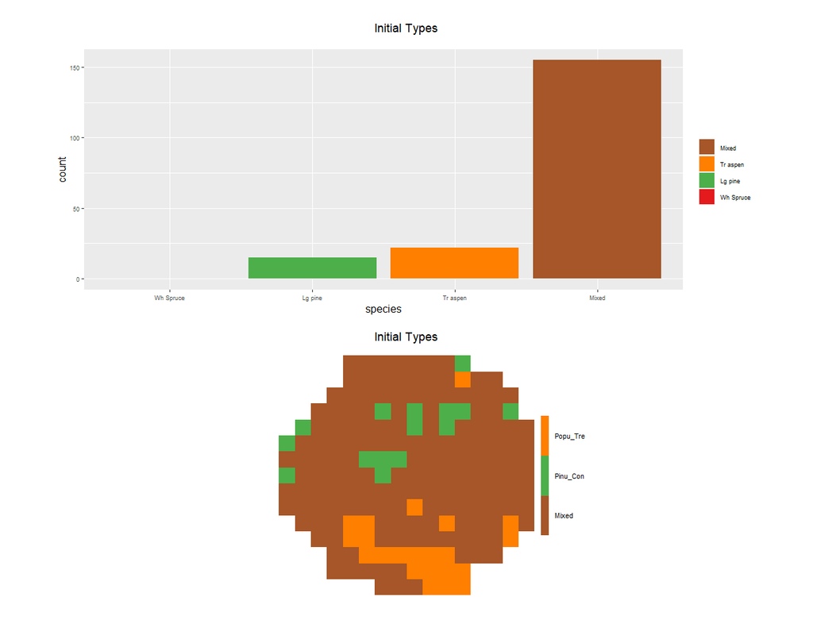

Figure 1: *Biomass_speciesData* automatically generates a plot of species dominance and number of presences in the study area when `.plotInitialTime=1` is passed as an argument.

## References

Beaudoin, A., Bernier, P.Y., Guindon, L., Villemaire, P., Guo, X.J., Stinson, G., *et al.* (2014). [Mapping attributes of Canada’s forests at moderate resolution through kNN and MODIS imagery](https://doi.org/10.1139/cjfr-2013-0401). *Canadian Journal of Forest Research*, 44, 521–532.

Beaudoin, A., Bernier, P.Y., Villemaire, P., Guindon, L. & Guo, X.J. (2017). [Species composition, forest properties and land cover types across canada’s forests at 250m resolution for 2001 and 2011](https://doi.org/10.23687/EC9E2659-1C29-4DDB-87A2-6ACED147A990).

Cosco, J. (2011). *COMMON ATTRIBUTE SCHEMA (CAS) FOR FOREST INVENTORIES ACROSS CANADA*. BOREAL AVIAN MODELLING PROJECT, CANADIAN BEACONs PROJECT.

Guindon, L., Manka, F., Correia, D.L.P., Villemaire, P., Smiley, B., Bernier, P., *et al.* (2024). [A new approach for spatializing the Canadian National Forest Inventory (SCANFI) using Landsat dense time series](https://doi.org/10.1139/cjfr-2023-0118). *Canadian Journal of Forest Research*, 54, 793–815.

Guindon, L., Villemaire, P., Correia, D.L.P., Manka, F., Lacarte, S. & Smiley, B. (2023). [SCANFI: The Spatialized CAnadian National Forest Inventory data product](https://doi.org/10.23687/18E6A919-53FD-41CE-B4E2-44A9707C52DC).

Hermosilla, T., Wulder, M.A., White, J.C., Coops, N.C., Bater, C.W. & Hobart, G.W. (2024). [Characterizing long-term tree species dynamics in Canada’s forested ecosystems using annual time series remote sensing data](https://doi.org/10.1016/j.foreco.2024.122313). *Forest Ecology and Management*, 572, 122313.

Pickell, P.D. & Coops, N.C. (2016). *Development of historical forest attribute layers using Landsat time series and kNN imputation for the western Canadian boreal forest*. University of British Columbia.

[^1]: Raw data layers downloaded by the module are saved in `dataPath(sim)`, which can be controlled via `options(reproducible.destinationPath = ...)`.